# Análisis descriptivo del Indicador de Seguimiento a la Economía (ISE), 2005-2026

## 7.6 Efecto de Semana Santa

El monthplot muestra que marzo y abril tienen mucha dispersión. Una explicación plausible es la Semana Santa: el Jueves y el Viernes Santo son festivos y caen en marzo o en abril según el año, lo que cambia el número de días hábiles de cada mes. Se verifica con los datos.

**Ver código**

```r
## Fecha del domingo de Pascua (algoritmo gregoriano de Meeus/Jones/Butcher)
fecha_pascua <- function(anio) {
  a <- anio %% 19; b <- anio %/% 100; c <- anio %% 100
  d <- b %/% 4; e <- b %% 4; f <- (b + 8) %/% 25; g <- (b - f + 1) %/% 3
  h <- (19 * a + b - d - g + 15) %% 30; i <- c %/% 4; k <- c %% 4
  l <- (32 + 2 * e + 2 * i - h - k) %% 7; m <- (a + 11 * h + 22 * l) %/% 451
  mes <- (h + l - 7 * m + 114) %/% 31; dia <- ((h + l - 7 * m + 114) %% 31) + 1
  as.Date(sprintf("%d-%02d-%02d", anio, mes, dia))
}

anios <- 2005:2026
jueves_santo <- fecha_pascua(anios) - 3
viernes_santo <- fecha_pascua(anios) - 2
festivos_ss <- c(jueves_santo, viernes_santo)

## Proporción de los dos festivos de Semana Santa que cae en cada mes (0, 0.5 o 1)
ss_nivel <- sapply(Fechas_ise, function(fm) sum(as.yearmon(festivos_ss) == fm) / 2)

## Años en que los festivos cayeron en marzo
anios_ss_marzo <- anios[month(viernes_santo) == 3]
anios_ss_marzo
```

```
[1] 2005 2008 2013 2016 2018 2024
```

**Ver código**

```r
## Crecimiento promedio de marzo y abril según el mes de Semana Santa (sin 2020)
dlise_df |>
  filter(mes %in% c("Mar", "Apr"), anio != 2020) |>
  mutate(semana_santa = if_else(anio %in% anios_ss_marzo, "En marzo", "En abril")) |>
  group_by(mes, semana_santa) |>
  summarise(crec_promedio = round(mean(crec), 2), n_anios = n(), .groups = "drop")
```

```
# A tibble: 4 × 4
  mes   semana_santa crec_promedio n_anios
  <fct> <chr>                <dbl>   <int>
1 Mar   En abril              4.59      15
2 Mar   En marzo              1.29       6
3 Apr   En abril             -3.93      15
4 Apr   En marzo              0.3        6
```

**Ver código**

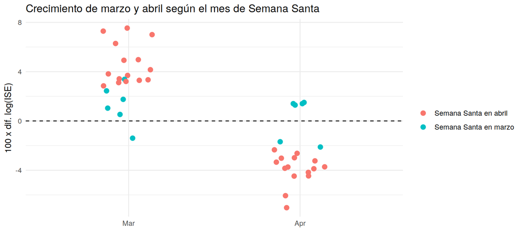

```r
dlise_df |>
  filter(mes %in% c("Mar", "Apr"), anio != 2020) |>
  mutate(semana_santa = if_else(anio %in% anios_ss_marzo, "Semana Santa en marzo", "Semana Santa en abril")) |>
  ggplot(aes(mes, crec, color = semana_santa)) +
  geom_jitter(width = 0.15, size = 2.5) +
  geom_hline(yintercept = 0, linetype = "dashed") +
  labs(title = "Crecimiento de marzo y abril según el mes de Semana Santa",
       x = NULL, y = "100 x dif. log(ISE)", color = NULL) +
  theme_minimal()
```

El efecto es claro. Cuando los festivos de Semana Santa caen en abril (15 de los 21 años), marzo crece en promedio 4,6 % y abril cae 3,9 %. Cuando caen en marzo, marzo crece solo 1,3 % y abril sube 0,3 %. Es un efecto calendario **móvil**, que unas dummies mensuales fijas no pueden capturar, así que se incluye como regresor en el modelamiento.

## 7.7 Estacionalidad estocástica

**Ver código**

```r
## Número de diferencias estacionales sugeridas (prueba basada en la fuerza estacional)
forecast::nsdiffs(lise)
```

```
[1] 1
```

**Ver código**

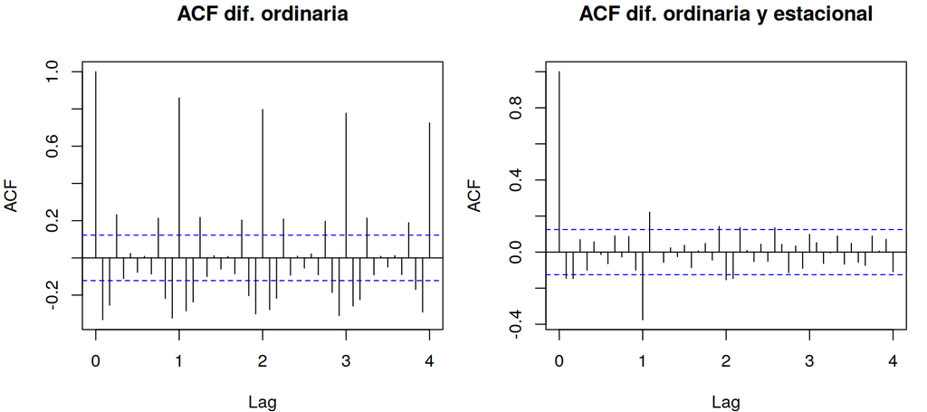

```r
par(mfrow = c(1, 2), mar = c(4, 4, 3, 1))
acf(dlise, 48, main = "ACF dif. ordinaria")
acf(diff(dlise, lag = 12), 48, main = "ACF dif. ordinaria y estacional")
```

**Ver código**

```r
par(mfrow = c(1, 1))
```

El ACF de la primera diferencia decae lentamente en los retardos 12, 24 y 36, y `nsdiffs()` sugiere una diferencia estacional. Al aplicarla, las autocorrelaciones estacionales caen de forma abrupta. Esto indica que parte de la estacionalidad podría ser estocástica y es un insumo para la etapa de modelos SARIMA. Para el análisis descriptivo, se modela la estacionalidad de forma determinística en la siguiente sección.